# Associations with DN Regulation

### TP Connectivity

DMN connectivity with the left fronto-parietal is significant with the others coming close (there does appear to be an outlier with the right frontoporietal network).

```r
# Combine
tmpdf <- data.frame(df[rep(1:nrow(df), length(network_names[tps])), c("Subject",
    "Age", "Sex", "prediction")], network = rep(network_names[tps], each = nrow(df)),
    connectivity = atanh(c(rest_conn)))
# Outliers
tmpdf <- ddply(tmpdf, .(network), function(sdf) {
    wrap_lmrob(prediction ~ Age + Sex + connectivity, sdf)
})
```

```
##
## Call:
## lmrob(formula = f, data = df, maxit.scale = 500)
##
## Weighted Residuals:
##     Min      1Q  Median      3Q     Max
## -0.1910 -0.0488 -0.0264  0.0683  0.1818
##
## Coefficients:
##              Estimate Std. Error t value Pr(>|t|)
## (Intercept)   0.26856    0.32996    0.81    0.439
## Age           0.00418    0.01641    0.25    0.805
## SexMale       0.08792    0.15409    0.57    0.584
## connectivity -0.62993    0.32440   -1.94    0.088 .
## ---
## Signif. codes:  0 '***' 0.001 '**' 0.01 '*' 0.05 '.' 0.1 ' ' 1
##
## Robust residual standard error: 0.0791
## Convergence in 21 IRWLS iterations
##
## Robustness weights:
##    Min. 1st Qu.  Median    Mean 3rd Qu.    Max.
##   0.540   0.901   0.956   0.887   0.987   0.998
## Algorithmic parameters:
## tuning.chi         bb tuning.psi refine.tol    rel.tol  solve.tol
##   1.55e+00   5.00e-01   4.69e+00   1.00e-07   1.00e-07   1.00e-07
##      nResample         max.it       best.r.s       k.fast.s          k.max
##            500             50              2              1            200
##    maxit.scale      trace.lev            mts     compute.rd fast.s.large.n
##            500              0           1000              0           2000
##           psi   subsampling        method           cov
##    "bisquare" "nonsingular"          "MM" ".vcov.avar1"
## seed : int(0)
##
## Call:
## lmrob(formula = f, data = df, maxit.scale = 500)
##
## Weighted Residuals:
##      Min       1Q   Median       3Q      Max
## -0.10799 -0.06937 -0.00653  0.06526  0.18125
```

[output cut: 46 more lines]

```
##
## Robustness weights:
##  one weight is ~= 1. The remaining 11 ones are summarized as
##    Min. 1st Qu.  Median    Mean 3rd Qu.    Max.
##   0.411   0.947   0.961   0.914   0.986   0.998
## Algorithmic parameters:
## tuning.chi         bb tuning.psi refine.tol    rel.tol  solve.tol
##   1.55e+00   5.00e-01   4.69e+00   1.00e-07   1.00e-07   1.00e-07
##      nResample         max.it       best.r.s       k.fast.s          k.max
##            500             50              2              1            200
##    maxit.scale      trace.lev            mts     compute.rd fast.s.large.n
##            500              0           1000              0           2000
##           psi   subsampling        method           cov
##    "bisquare" "nonsingular"          "MM" ".vcov.avar1"
## seed : int(0)
```

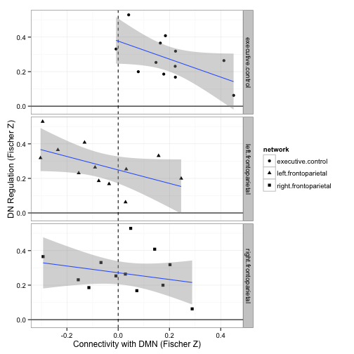

```r
# Plot
ggplot(tmpdf, aes(x = connectivity, y = prediction, shape = network)) + geom_vline(aes(xintercept = 0),
    linetype = "dashed") + geom_hline(aes(yintercept = 0)) + geom_point() +
    geom_smooth(method = rlm) + facet_grid(network ~ .) + labs(x = "Connectivity with DMN (Fischer Z)",
    y = "DN Regulation (Fischer Z)")
```

### MDMR

Had to throw this in. The first analysis is significant, so the pattern of connectivity between the DMN and the other networks significantly predicts real-time prediction accuracy.

```r
# CWAS between DMN and all networks
d <- as.dist(1 - cor(t(rest_conn_all[, -4, 4])))
adonis(d ~ Age + Sex + prediction, df, permutations = 4999)
```

```
##
## Call:
## adonis(formula = d ~ Age + Sex + prediction, data = df, permutations = 4999)
##
## Terms added sequentially (first to last)
##
##            Df SumsOfSqs MeanSqs F.Model    R2 Pr(>F)
## Age         1     0.386   0.386    3.45 0.136 0.0414 *
## Sex         1     0.922   0.922    8.24 0.325 0.0004 ***
## prediction  1     0.634   0.634    5.66 0.223 0.0054 **
## Residuals   8     0.895   0.112         0.316
## Total      11     2.837                 1.000
## ---
## Signif. codes:  0 '***' 0.001 '**' 0.01 '*' 0.05 '.' 0.1 ' ' 1
```

```r
# CWAS between DMN and TP networks
d <- as.dist(1 - cor(t(rest_conn)))
adonis(d ~ Age + Sex + prediction, df, permutations = 4999)
```

```
##
## Call:
## adonis(formula = d ~ Age + Sex + prediction, data = df, permutations = 4999)
##
## Terms added sequentially (first to last)
##
##            Df SumsOfSqs MeanSqs F.Model     R2 Pr(>F)
## Age         1      1.68   1.684    4.06  0.308  0.064 .
## Sex         1      0.59   0.594    1.43  0.109  0.261
## prediction  1     -0.13  -0.130   -0.31 -0.024  0.950
## Residuals   8      3.31   0.414          0.607
## Total      11      5.46                  1.000
## ---
## Signif. codes:  0 '***' 0.001 '**' 0.01 '*' 0.05 '.' 0.1 ' ' 1
```

### with Phenotypic Measures

```r
brainbehavior.multiple <- function(names, with_age_sex = TRUE) {
    # Significance
    if (with_age_sex)
        f <- paste("prediction ~ Age + Sex +", paste(names, collapse = " + ")) else f <- paste("prediction ~", paste(names, collapse = " + "))
    f <- as.formula(f)
    tdf <- wrap_lmrob(f, df)

    # Reorganize
    tdf$id <- 1:nrow(tdf)
    bb.df <- ddply(tdf, .(Subject), function(sdf) {
        sdf <- data.frame(sdf[rep(1, length(names)), c("id", "Subject", "prediction",
            "outlier", "weights")], measure = names, behavior = as.numeric(sdf[,
            names]))
        sdf
    })

    # Get best fit line
    model <- lmrob(prediction ~ behavior + measure, bb.df, maxit.scale = 500)
    grid <- ddply(bb.df[bb.df$outlier == "no", ], .(measure), function(sdf) {
        data.frame(behavior = seq(min(sdf$behavior), max(sdf$behavior), length = 20),
            measure = rep(sdf$measure[1], 20))
    })
    grid$prediction <- predict(model, newdata = grid)

    # Plot
    p0 <- ggplot(bb.df, aes(x = behavior, y = prediction)) + geom_hline(aes(yintercept = 0)) +
        ylim(0, 0.6) + xlab("Scale Score") + ylab("DN Regulation (Fischer Z)") +
        facet_grid(. ~ measure, scales = "free_x")
    if (any(bb.df$outlier == "yes")) {
        p <- p0 + geom_point(data = bb.df[bb.df$outlier == "yes", ], size = 8,
            color = brewer.pal(3, "Pastel1")[1]) + geom_point(aes(color = measure),
            shape = 1, size = 8) + geom_text(aes(label = id), size = 5) + geom_line(data = grid,
            color = "blue") + scale_color_discrete(name = "Measure")
    } else {
        p <- p0 + geom_point(aes(color = measure), shape = 1, size = 8) + geom_text(aes(label = id),
            size = 5) + geom_line(data = grid, color = "blue") + scale_color_discrete(name = "Measure")
    }
    p
}
brainbehavior.single <- function(names, with_age_sex = TRUE) {
    # Significance
    bb.df <- ldply(names, function(name) {
        cat("\nRunning regression for", name, "\n")
        if (with_age_sex)
            f <- paste("prediction ~ Age + Sex +", name) else f <- paste("prediction ~", name)
        f <- as.formula(f)
        tdf <- wrap_lmrob(f, df)
        tdf$id <- 1:nrow(tdf)
        tdf$measure <- name
        tdf$behavior <- tdf[[name]]
        cat("\n")
        tdf[, c("id", "Subject", "measure", "behavior", "prediction", "outlier",
            "weights")]
    })
    bb.df$measure <- factor(bb.df$measure)
    bb.df$outlier <- factor(bb.df$outlier)


    # Get best fit line
    grid <- ddply(bb.df[bb.df$outlier == "no", ], .(measure), function(sdf) {
        model <- lmrob(prediction ~ behavior, sdf, maxit.scale = 500)
        sgrid <- data.frame(behavior = seq(min(sdf$behavior), max(sdf$behavior),
            length = 20))
        sgrid$prediction <- predict(model, newdata = sgrid)
        sgrid$measure <- sdf$measure[1]
        sgrid
    })

    # Plot
    p0 <- ggplot(bb.df, aes(x = behavior, y = prediction)) + geom_hline(aes(yintercept = 0)) +
        ylim(0, 0.6) + xlab("Scale Score") + ylab("DN Regulation (Fischer Z)") +
        facet_grid(. ~ measure, scales = "free_x")
    if (any(bb.df$outlier == "yes")) {
        p <- p0 + geom_point(data = bb.df[bb.df$outlier == "yes", ], size = 8,
            color = brewer.pal(3, "Pastel1")[1]) + geom_point(aes(color = measure),
            shape = 1, size = 8) + geom_text(aes(label = id), size = 5) + geom_line(data = grid,
            color = "blue") + scale_color_discrete(name = "Measure")
    } else {
        p <- p0 + geom_point(aes(color = measure), shape = 1, size = 8) + geom_text(aes(label = id),
            size = 5) + geom_line(data = grid, color = "blue") + scale_color_discrete(name = "Measure")
    }
    p
}
```

#### Total Scale Scores (with BDI, without PANAS)

##### Multiple Regression

Here, only RRS is significant and there are no outliers.

```r
names <- c("SIPI", "RRS", "ERQ", "BDI", "AIM")
brainbehavior.multiple(names)
```

```
##
## Call:
## lmrob(formula = f, data = df, maxit.scale = 500)
##
## Weighted Residuals:
##  [1]  0.06852 -0.03118 -0.06311 -0.11458  0.00576  0.00660  0.04756
##  [8]  0.02620  0.02813 -0.01335 -0.05456  0.08936
##
## Coefficients:
##              Estimate Std. Error t value Pr(>|t|)
## (Intercept) -0.000170   0.949732    0.00    1.000
## Age         -0.004226   0.008257   -0.51    0.636
## SexMale     -0.109856   0.167760   -0.65    0.548
## SIPI         0.001894   0.003943    0.48    0.656
## RRS          0.009706   0.002759    3.52    0.024 *
## ERQ         -0.005241   0.006807   -0.77    0.484
## BDI         -0.013251   0.023601   -0.56    0.604
## AIM          0.000329   0.001672    0.20    0.854
## ---
## Signif. codes:  0 '***' 0.001 '**' 0.01 '*' 0.05 '.' 0.1 ' ' 1
##
## Robust residual standard error: 0.121
## Convergence in 9 IRWLS iterations
##
## Robustness weights:
##  2 weights are ~= 1. The remaining 10 ones are
##     1     2     3     4     7     8     9    10    11    12
## 0.971 0.994 0.975 0.920 0.986 0.996 0.995 0.999 0.982 0.951
## Algorithmic parameters:
## tuning.chi         bb tuning.psi refine.tol    rel.tol  solve.tol
##   1.55e+00   5.00e-01   4.69e+00   1.00e-07   1.00e-07   1.00e-07
##      nResample         max.it       best.r.s       k.fast.s          k.max
##            500             50              2              1            200
##    maxit.scale      trace.lev            mts     compute.rd fast.s.large.n
##            500              0           1000              0           2000
##           psi   subsampling        method           cov
##    "bisquare" "nonsingular"          "MM" ".vcov.avar1"
## seed : int(0)
```

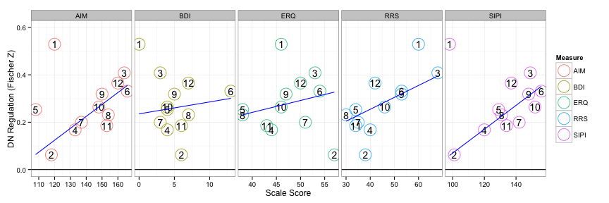